# Trabalho final - Análise de dados 2021/1

*Coeficientes: Quanto aos coeficientes, o intercepto sinaliza que se as demais variáveis independentes forem 0 a chance de um candidato ser eleito diminui em 74,72%, ou seja, um homem, não branco e não casado, tem 74,72% menos chances de ser eleito. Em relação a variável gênero,o coeficiente obtido no valor de 0,7664, indica que as mulheres tem 23,36% menos chances de ser eleitas. A partir da regressão2, também inferimos que é 0,6978 menos provável que um candidato não branco seja eleito, ou seja, as chances de ser eleito é 30,22% menor para candidatos não brancos. Na variável casado, o coeficiente no valor de 0,9328, tendo como categoria de referência zero (nesse caso, não casado) indica que um candidato não casado tem 6,72% menos chances de ser eleito do que um candidato casado.Sobre a variável log_bens, podemos inferir que a chance de um candidato com maior valores de bens é 61,34% maior do que candidatos com baixo valor de bens.

```r
margins::margins_summary(regressão2)
```

```
##    factor     AME     SE       z      p   lower   upper
##   Casado0 -0.0061 0.0086 -0.7018 0.4828 -0.0230  0.0108
##    Gênero -0.0218 0.0098 -2.2200 0.0264 -0.0411 -0.0026
##  Log_Bens  0.0300 0.0021 14.3169 0.0000  0.0259  0.0341
##     Raça0 -0.0299 0.0086 -3.4665 0.0005 -0.0467 -0.0130
```

Podemos interpretar os coeficientes também, através da probabilidade de tal evento acontecer. Conforme mostrado acima, não ser casado diminuiu a probabilidade de ser eleito em 0,6%. Na variável gênero inferimos que as mulheres, em média, tem uma probabilidade de 2,18% menor do que os homens de serem eleitas.Na variável raça, vimos que não ser branco diminui em 2,9% a probabilidade de eleição. Na variável log_bens, vemos que o aumento em 1% na renda do candidato, aumenta em 3% a chance desse candidato ser eleito.

*Importância das variáveis

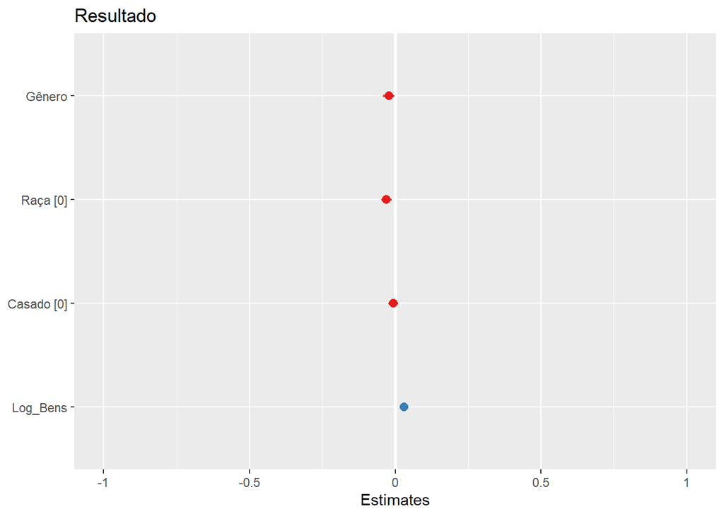

```r
library(sjPlot)
plot_model(regressão2)
```

*Pressupostos da regressão

1. Ausência de outliers:

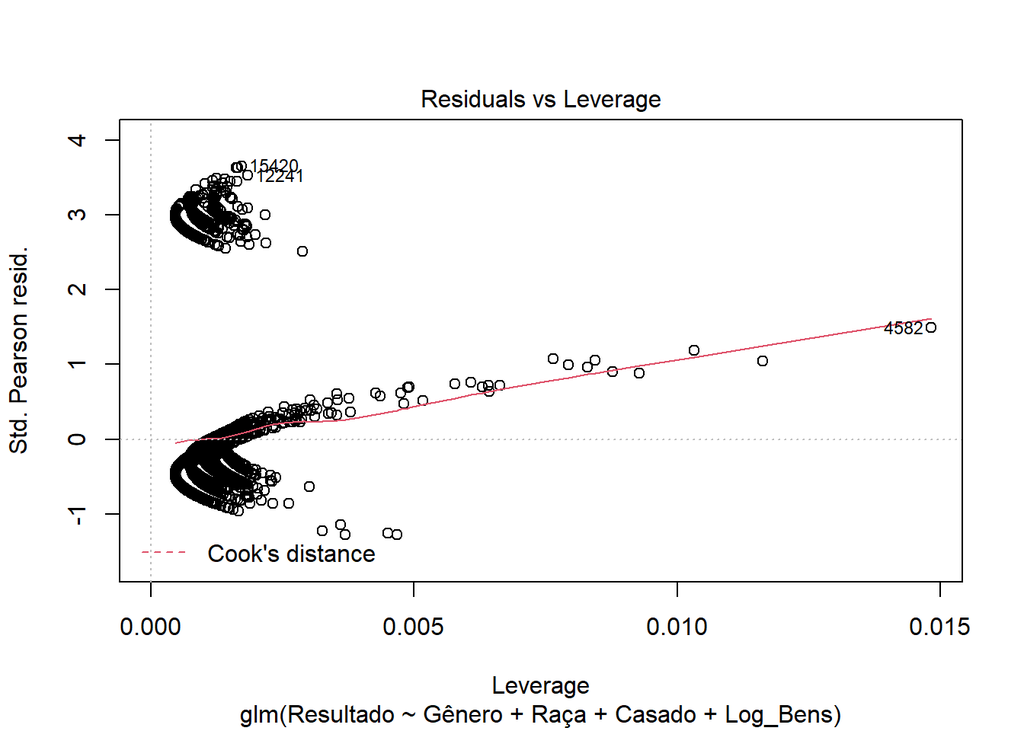

```r
plot(regressão2, which = 5)
```

```r
summary(stdres(regressão2))
```

```
##      Min.   1st Qu.    Median      Mean   3rd Qu.      Max.
## -1.283679 -0.460379 -0.314034  0.000021 -0.117313  3.654665
```

Esse pressuposto não foi atendido, pois o valor máximo ultrapassou o valor três. Para o pressuposto ser atendido o valor mínimo e máximo devem ficar entre o intervalo -3 e 3. No gráfico abaixo podemos ver a presença de outliers.

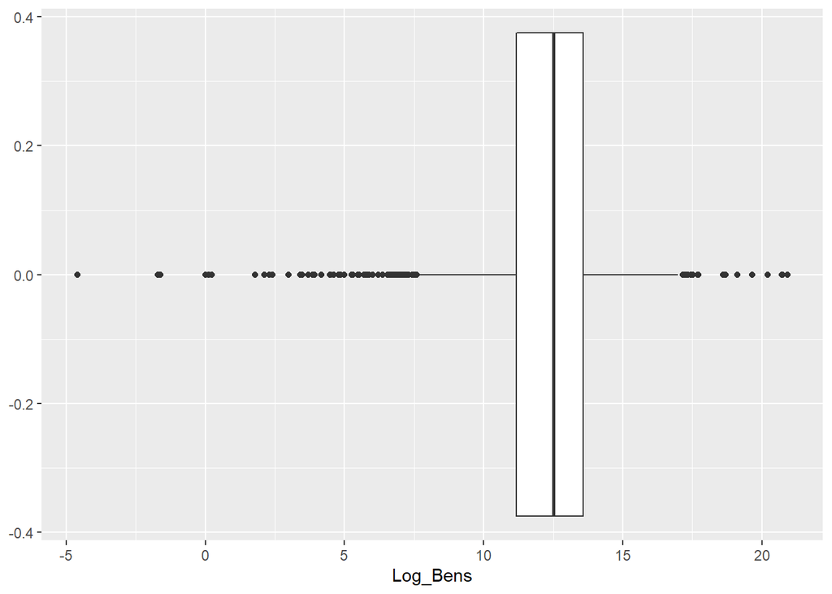

```r
ggplot(banco_selecionado, aes(Log_Bens))+
   geom_boxplot()
```

2. Ausência de multicolinearidade:

```r
require(faraway)
vif(regressão2)
```

```
##   Gênero    Raça0  Casado0 Log_Bens
## 1.048302 1.033075 1.050413 1.087368
```

Os VIFs medem a variância de um coeficiente da regressão aumenta se as variáveis independentes estão correlacionadas.Nesse caso, não há multicolinearidade pois os valores encontrados após o teste VIF são baixos.